# Predicting Sleep Quality

James San

UCSB Fall 2023

## Introduction

The main purpose of this project is to build a model that will be able to predict the quality of sleep based on a multitude of internal and external factors affecting a person. We will be using data sourced from Kaggle to generate machine learning models, find the most most accurate model, and make accurate predictions for this classification problem.

[figure not shown]

## Why Sleep?

Sleep is one of the most important functions for the human body as consistent, quality, sleep is often needed for good health. When your body goes to sleep your brain is still working, it goes through a repairment process by first removing waste and toxins. Everything from blood vessels to your immune system rely on sleep to repair. Thus. a lack of quality sleep often leads to larger issues down the line by raising the risks of many diseases and disorders. According to the Centers for Disease Control and Prevention, in 2020 it was reported that 14.5 percent of adults in Ameica had trouble falling asleep most days with this number continuing to rise.

## What Are We Trying to Do?

With all the data readily available to us we can try to find correlations and relationships between a lifestyle and sleep quality to best predict what may cause or not cause good sleep. This will be a classification problem as we rank sleep quality from a number 1-10, 10 being the best possible sleep and 1 being the worst. Using factors ranging from age, heart rate, etc. we can ask, Does occupation affect sleep quality? What about physical activity level throughout the day? We can develop models and see if sleep quality levels can be explained by these elements.

## Project Roadmap

To build this project we start with data manipulation and cleaning to prepare our data for modeling. We then move onto exploratory data analysis to learn more about our predictor and outcome variables, notice any relationships and correlations. Afterwards we will conduct a training and testing split of the data, create a recipe for our models, and make a k-fold cross validation to train our data. Following this we will create and run our models, I have decided on 4 models, elastic net, k-nearest neighbors, random forest, and boosted trees. We will then find the model that performed the best based on the metrics and see how well it can predict quality of sleep.

## Loading Packages and Data

We begin by loading in our raw data and packages and factor our variables.

```r
library(tidyverse, quietly = T)
library(dplyr, quietly = T)
library(tidymodels, quietly = T)
library(readr, quietly = T)
library(kknn, quietly = T)
library(janitor, quietly = T)
library(ISLR, quietly = T)
library(knitr, quietly = T)
library(MASS, quietly = T)
library(discrim, quietly = T)
library(poissonreg, quietly = T)
library(glmnet, quietly = T)
library(corrr, quietly = T)
library(corrplot, quietly = T)
library(randomForest, quietly = T)
library(xgboost, quietly = T)
library(rpart.plot, quietly = T)
library(vip, quietly = T)
library(ranger, quietly = T)
library(tidytext, quietly = T)
library(ggplot2, quietly = T)
library(themis, quietly = T)
library(varhandle, quietly = T)
tidymodels_prefer()

#Setting working directory and assigning data set to variable, sleep.
setwd("C:/Users/James San/Downloads/Pstat 131/131 Project")
sleep <- read_csv("SleepDataset.csv", show_col_types = FALSE)
sleep <- clean_names(sleep) #clean variable names
```

Data is from the Kaggle data set, [Sleep and Lifestyle Dataset](https://www.kaggle.com/datasets/uom190346a/sleep-health-and-lifestyle-dataset/data), by user Lakiska Tharmalingam.

## Exploratory Data Analysis

We need to get our data ready for application by seeing which variables need manipulating or tidying. Furthermore, we need to check for any missing values or if any variables needs to be factorized. This step will allow us to then explore relationships and generate models without issues within the data itself.

### Exploring and Tidying Raw Data

```r
#Looking at the first few observations to see if data set was assigned properly, also checking dimensions of data set.
sleep %>%
  head()
```

```
## # A tibble: 6 × 13
##   person_id gender   age occupation           sleep_duration quality_of_sleep
##       <dbl> <chr>  <dbl> <chr>                         <dbl>            <dbl>
## 1         1 Male      27 Software Engineer               6.1                6
## 2         2 Male      28 Doctor                          6.2                6
## 3         3 Male      28 Doctor                          6.2                6
## 4         4 Male      28 Sales Representative            5.9                4
## 5         5 Male      28 Sales Representative            5.9                4
## 6         6 Male      28 Software Engineer               5.9                4
## # ℹ 7 more variables: physical_activity_level <dbl>, stress_level <dbl>,
## #   bmi_category <chr>, blood_pressure <chr>, heart_rate <dbl>,
## #   daily_steps <dbl>, sleep_disorder <chr>
```

```r
dim(sleep)
```

```
## [1] 374  13
```

There are 374 observations, 374 different people who were gathered data on, and 13 variables. Our response variable is sleep quality as that is what we are trying to predict, therefore we have 12 predictor variables which is a good amount. Further checking the variable descriptions it seems that they all may have a direct impact on sleep quality so we will keep them all.

#### Tidying BMI Category Variable

```r
sleep[ , "bmi_category"] <- if_else(sleep$bmi_category == 'Normal Weight', 'Normal',sleep$bmi_category)
```

#### Tidying Blood Pressure Variable

Moving on, I noticed the Blood Pressure Variable was a character variable in the form of ‘systolic number / diastolic number’. This could cause complications when modeling and for readability so we will instead change the values to Low, Normal, Elevated, High Stage 1 , High Stage 2, and Hypertension Crisis.

```r
BloodPressureSplit<-str_split(sleep$blood_pressure,'/')

Systolic <- lapply(BloodPressureSplit,function(x) x[1])
Systolic <- as.numeric(Systolic)

Diastolic <- lapply(BloodPressureSplit, function(x) x[2])
Diastolic <- as.numeric(Diastolic)


sleep[ ,"blood_pressure"] <- if_else(Systolic < 120 & Diastolic < 80, 'Normal', sleep$blood_pressure)

sleep[ ,"blood_pressure"] <- if_else(Systolic < 90 & Diastolic < 60, 'Low', sleep$blood_pressure)

sleep[ ,"blood_pressure"] <- if_else(Systolic >= 120 & Systolic <= 129 | Diastolic >= 80 & Diastolic <= 84, 'Elevated', sleep$blood_pressure)

sleep[ ,"blood_pressure"] <- if_else(Systolic >= 130 & Systolic <= 139 | Diastolic >= 85 & Diastolic >= 89, 'High Stage 1', sleep$blood_pressure)

sleep[ ,"blood_pressure"] <- if_else(Systolic >= 140 | Diastolic >= 90, 'High Stage 2', sleep$blood_pressure)

sleep[ ,"blood_pressure"] <- if_else(Systolic >= 180 & Diastolic >= 120 | Diastolic >= 120, 'Hypertension Crisis', sleep$blood_pressure)
```

Blood Pressure Levels were sourced from Harvard Health.

#### Tidying Occupation Variable

There are 11 unique occupations in this data set but we can further lower it. Sales Representative appears only twice in the data and since it’s one in the same with Salesperson we can combine the two. We can also combine software engineer with engineer as they are both the same field. Furthermore, there is only one observation with Manager and four observations with scientists so it would not be very telling in its relationship with sleep quality so we will remove it.

```r
unique(sleep$occupation)
```

```
##  [1] "Software Engineer"    "Doctor"               "Sales Representative"
##  [4] "Teacher"              "Nurse"                "Engineer"
##  [7] "Accountant"           "Scientist"            "Lawyer"
## [10] "Salesperson"          "Manager"
```

```r
table(sleep$occupation)
```

```
##
##           Accountant               Doctor             Engineer
##                   37                   71                   63
##               Lawyer              Manager                Nurse
##                   47                    1                   73
## Sales Representative          Salesperson            Scientist
##                    2                   32                    4
##    Software Engineer              Teacher
##                    4                   40
```

```r
sleep[ ,"occupation"] <- if_else(sleep$occupation == "Sales Representative", "Salesperson", sleep$occupation)

sleep[ ,"occupation"] <- if_else(sleep$occupation == "Software Engineer", "Engineer", sleep$occupation)

sleep %>%
filter(occupation == "Manager")
```

```
## # A tibble: 1 × 13
##   person_id gender   age occupation sleep_duration quality_of_sleep
##       <dbl> <chr>  <dbl> <chr>               <dbl>            <dbl>
## 1       264 Female    45 Manager               6.9                7
## # ℹ 7 more variables: physical_activity_level <dbl>, stress_level <dbl>,
## #   bmi_category <chr>, blood_pressure <chr>, heart_rate <dbl>,
## #   daily_steps <dbl>, sleep_disorder <chr>
```

```r
sleep = filter(sleep, occupation != "Manager")

sleep %>%
  filter(occupation == "Scientist")
```

```
## # A tibble: 4 × 13
##   person_id gender   age occupation sleep_duration quality_of_sleep
##       <dbl> <chr>  <dbl> <chr>               <dbl>            <dbl>
## 1        69 Female    33 Scientist             6.2                6
## 2        70 Female    33 Scientist             6.2                6
## 3        81 Female    34 Scientist             5.8                4
## 4        82 Female    34 Scientist             5.8                4
## # ℹ 7 more variables: physical_activity_level <dbl>, stress_level <dbl>,
## #   bmi_category <chr>, blood_pressure <chr>, heart_rate <dbl>,
## #   daily_steps <dbl>, sleep_disorder <chr>
```

```r
sleep = filter(sleep, occupation != "Scientist")
```

#### Tidying Quality of Sleep Variable

Because the quality of sleep variable only has 3 observations where the rating is 4 and 7 observations where the rating is 5, since those are too few observations we have to remove them as it could affect our models later on.

```r
table(sleep$quality_of_sleep)
```

```
##
##   4   5   6   7   8   9
##   3   7 103  76 109  71
```

```r
sleep = filter(sleep, quality_of_sleep != 4)
sleep = filter(sleep, quality_of_sleep != 5)
```

### Factoring Variables

We factorize the categorical variables. However, we drop the factor levels where there are not any observations that have that factor.

```r
sleep$quality_of_sleep <- factor(sleep$quality_of_sleep)
sleep$gender <- factor(sleep$gender, ordered = TRUE, levels = c('Male','Female'))
sleep$bmi_category <- factor(sleep$bmi_category)
sleep$sleep_disorder <- factor(sleep$sleep_disorder)
sleep$blood_pressure<-factor(sleep$blood_pressure)
sleep$stress_level<- factor(sleep$stress_level)
sleep$occupation <- factor(sleep$occupation)

levels(sleep$quality_of_sleep)
```

```
## [1] "6" "7" "8" "9"
```

### Check for Missing Values

We have to check if there are any missing values in the data as it could affect our models later on.

```r
summary(sleep)
```

```
##    person_id        gender         age              occupation sleep_duration
##  Min.   :  1.0   Male  :183   Min.   :27.00   Accountant :37   Min.   :5.900
##  1st Qu.:101.5   Female:176   1st Qu.:36.00   Doctor     :71   1st Qu.:6.500
##  Median :194.0                Median :43.00   Engineer   :65   Median :7.200
##  Mean   :192.4                Mean   :42.58   Lawyer     :47   Mean   :7.168
##  3rd Qu.:284.5                3rd Qu.:50.00   Nurse      :69   3rd Qu.:7.800
##  Max.   :374.0                Max.   :59.00   Salesperson:32   Max.   :8.500
##                                               Teacher    :38
##  quality_of_sleep physical_activity_level stress_level     bmi_category
##  6:103            Min.   :30.00           3:71         Normal    :212
##  7: 76            1st Qu.:45.00           4:70         Obese     :  7
##  8:109            Median :60.00           5:66         Overweight:140
##  9: 71            Mean   :60.06           6:44
##                   3rd Qu.:75.00           7:43
##                   Max.   :90.00           8:65
##
##       blood_pressure   heart_rate     daily_steps        sleep_disorder
##  Elevated    :120    Min.   :65.00   Min.   : 3300   Insomnia   : 72
##  High Stage 1:101    1st Qu.:68.00   1st Qu.: 6000   None       :216
##  High Stage 2: 97    Median :70.00   Median : 7000   Sleep Apnea: 71
##  Normal      : 41    Mean   :69.79   Mean   : 6919
##                      3rd Qu.:72.00   3rd Qu.: 8000
##                      Max.   :86.00   Max.   :10000
##
```

```r
head(sleep) #One last check on our data
```

```
## # A tibble: 6 × 13
##   person_id gender   age occupation sleep_duration quality_of_sleep
##       <dbl> <ord>  <dbl> <fct>               <dbl> <fct>
## 1         1 Male      27 Engineer              6.1 6
## 2         2 Male      28 Doctor                6.2 6
## 3         3 Male      28 Doctor                6.2 6
## 4         7 Male      29 Teacher               6.3 6
## 5         8 Male      29 Doctor                7.8 7
## 6         9 Male      29 Doctor                7.8 7
## # ℹ 7 more variables: physical_activity_level <dbl>, stress_level <fct>,
## #   bmi_category <fct>, blood_pressure <fct>, heart_rate <dbl>,
## #   daily_steps <dbl>, sleep_disorder <fct>
```

```r
dim(sleep)
```

```
## [1] 359  13
```

Looking at the summary of the data, there are in fact no missing values. Also looking at the dimensions we end up with 359 total which was brought down from 374.

### Predictor Variables

As a result of our exploratory data analysis we have confirmed which variables we will be using in our models to predict sleep quality.

- `Person ID` : The unique identifier for each individual.
- `Gender` : Sex of the individual, Male/Female.
- `Age` : Age of the individual in years.
- `Occupation` : The individual’s profession.
- `Sleep Duration` : How many hours the individual sleeps in a day.
- `Physical Activity Level` : Number of minutes an individual does physical activity in a day.
- `Stress Level` : Stress level on a scale from 1-10 rated by the individual.
- `BMI Category` : BMI Category of the individual, Underweight, Normal, Overweight, Obese.
- `Blood Pressure` : Blood Pressure level of the individual, Low, Normal, Elevated, High Stage 1, Stage 2, and Hypertension Crisis.
- `Heart Rate` : Resting heart rate of the individual measured in beats per minute.
- `Daily Steps` : Number of steps the individual takes in a single day.
- `Sleep Disorder` : If the individual has a sleep disorder being None, Insomnia, or Sleep Apnea.

## Visual EDA

With our data tidied we can now create visualizations and look for relationships between the variables.

#### Sleep Quality

Let’s start by checking out our outcome variable, sleep quality. We create a bar plot to see the distribution.

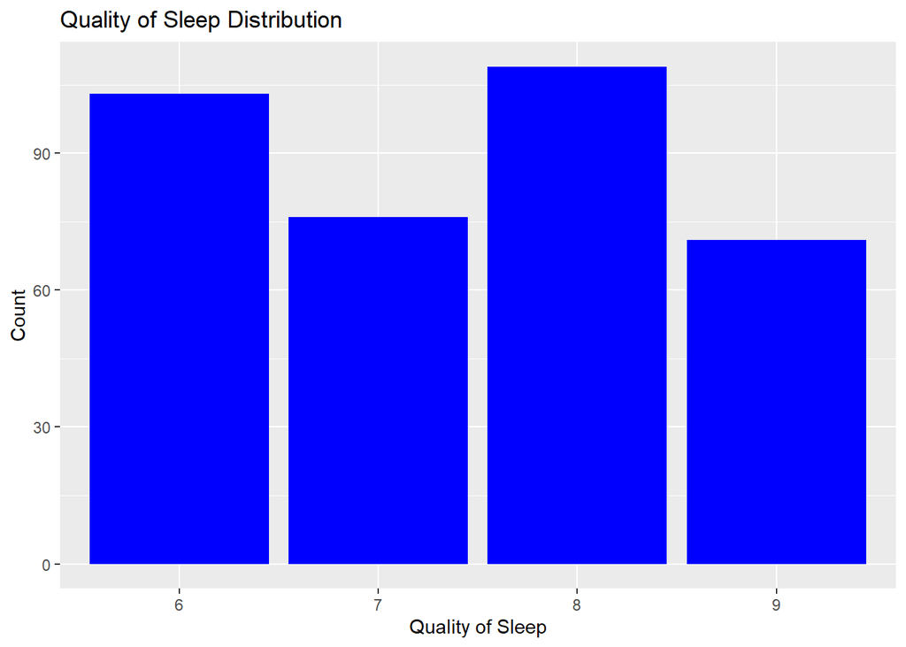

```r
sleep %>%
  ggplot(aes(x=quality_of_sleep)) + geom_bar(fill='blue') + labs(x='Quality of Sleep',y='Count',title = "Quality of Sleep Distribution")
```

```r
table(sleep$quality_of_sleep)
```

```
##
##   6   7   8   9
## 103  76 109  71
```

A majority of individuals appeared to have rated their quality of sleep between 6-9, 8 being the highest with 109 observations, with no one actually rating their sleep a 10 or below a 4. What surprised me was there were only 12 individuals who had rated their sleep below 6 which is around 3.2%, I would have expected more.

### Occupation

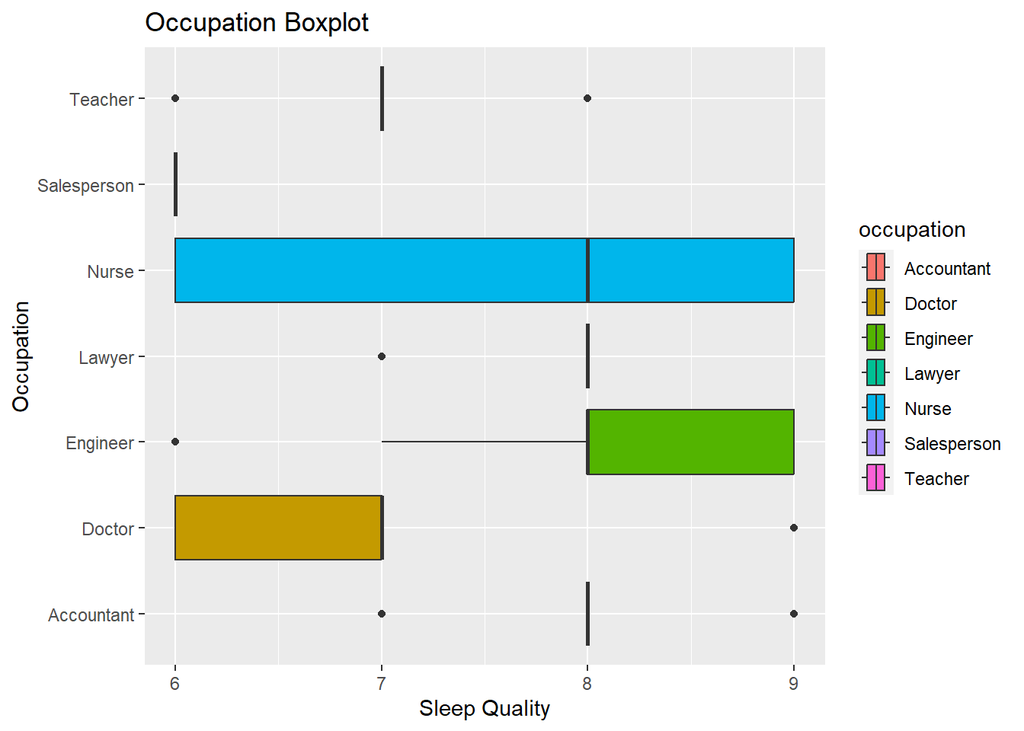

```r
sleep %>%
  ggplot(aes(x= unfactor(quality_of_sleep) , y = occupation, fill = occupation)) + geom_boxplot() +
  labs(title = 'Occupation Boxplot',
        y = "Occupation",
        x = "Sleep Quality")
```

Looking at the box plot we can find the average ratings of sleep quality for each occupation. Engineers, Lawyers, and Accountants have the highest average with 8! I thought this was especially surprising due to the fact that these jobs have the stigma of being in a more demanding environment. In the bottom we have salesperson which has an average rating of 6.

Looking at the spread of each occupation, Nurses has the largest spreads meaning it had diverse ratings between individuals. On the other hand, Teachers, Salespeople, Lawyers, and Accountants have no spread, so their individuals all were in concurrence with their ratings.

### Variable Correlation Plot

We create a correlation plot to look for any relationships between the continuous variables.

Since we had factored quality of sleep and stress levels they are no longer numeric but if we want to visualize correlations between the outcome and predictor variables we can change them to numeric for the correlation graph.

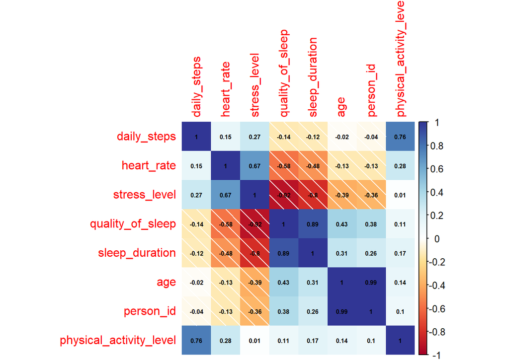

```r
#Change to Numeric
is.numeric(sleep$quality_of_sleep)
is.numeric(sleep$stress_level)

sleep$quality_of_sleep<- as.numeric(as.character(sleep$quality_of_sleep))
sleep$stress_level <- as.numeric(as.character(sleep$stress_level))


sleep_numeric <- sleep %>%
  select_if(is.numeric)

#Correlation matrix
sleep_cor <- cor(sleep_numeric)

#Visualization of correlation plot
sleep_cor_plot <- corrplot(sleep_cor,order = 'AOE', method = 'shade', addCoef.col = 1.5, number.cex = 0.5, col = COL2('RdYlBu'))
```

```r
#Change back to factor
sleep$stress_level <- factor(sleep$stress_level)
sleep$quality_of_sleep <- factor(sleep$quality_of_sleep)

is.factor(sleep$quality_of_sleep)
is.factor(sleep$stress_level)
```

Some interesting finds is the variables with high negative correlations with the outcome variable, Quality of Sleep, are Heart Rate (-0.58) and Stress Level (-0.92). This would make sense as higher stress levels and heart rate would cause someone to struggle with sleep. Age has a positive correlation with 0.43, and I was surprised to see that Physical Activity Level had a low positive correlation with 0.11 and Daily steps actually had a low negative correlation with -0.14 respectively. I had thought someone who had done higher amounts of physical activity would find it much easier to sleep so high positive correlation was expected.

### Stress Level and Sleep Quality

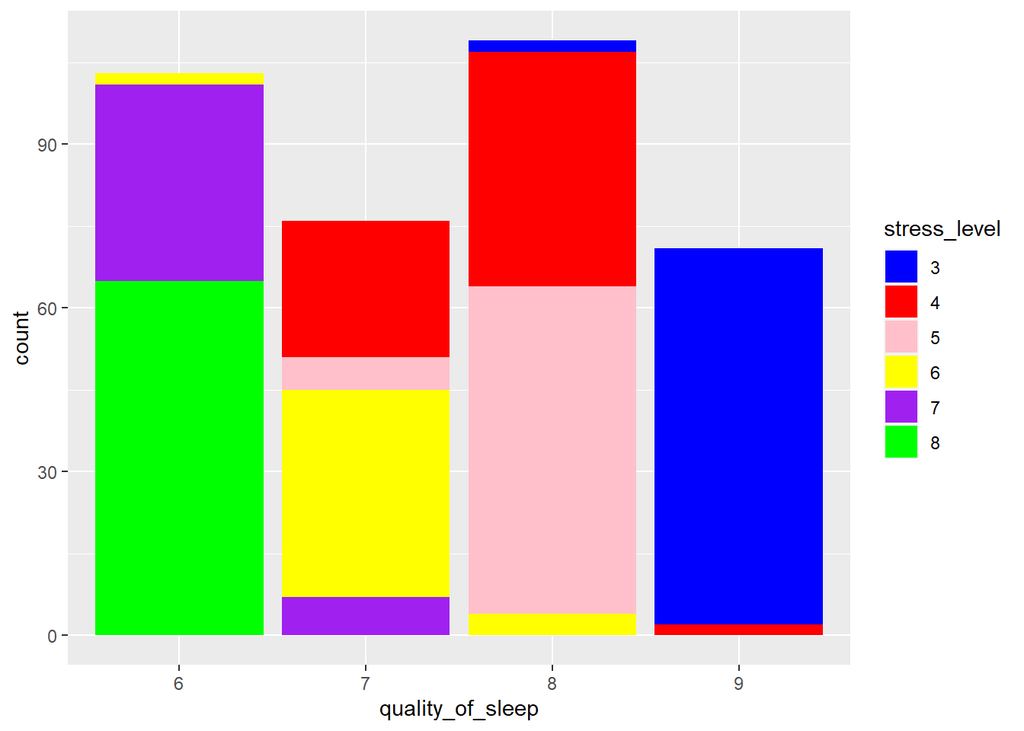

```r
ggplot(sleep, aes(quality_of_sleep)) +
  geom_bar(aes(fill = stress_level)) +
  scale_fill_manual(values = c("blue", "red","pink", "yellow","purple", "green"))
```

As we can see in the stacked bar chart, the sleep quality ratings in the higher range are dominated by individuals whose stress levels are at 5 and below. Upon further inspection, the bar for sleep quality rating 9 is filled with nearly all individuals with a stress level of 3. This alone shows us that sleep quality and stress are in fact correlated with better sleep quality attributing to lower stress.

### BMI and Sleep Quality

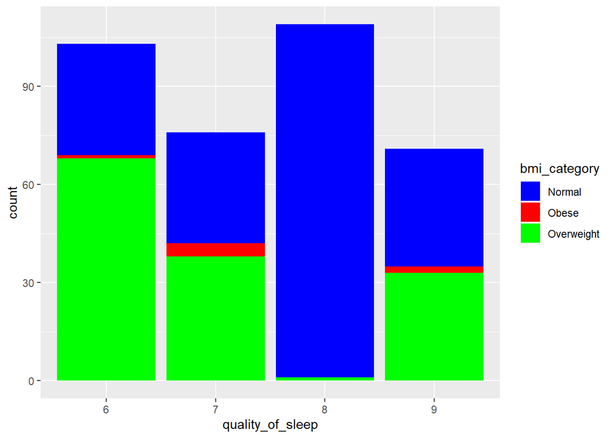

```r
ggplot(sleep, aes(quality_of_sleep)) +
  geom_bar(aes(fill = bmi_category)) +
  scale_fill_manual(values = c("blue", "red", "green"))
```

### Blood Pressure and Sleep Quality

Next we will compare blood pressure and sleep quality. Blood Pressure is categorized in 6 levels, low, normal, elevated, high stage 1, stage 2, and hypertension crisis. Higher blood pressure causes a multitude of issues within the body such as headaches and difficulty breathing, let’s see how this affects the relationship with sleep quality. From our data set we did not have any individuals with blood pressure levels of hypertension crisis or low.

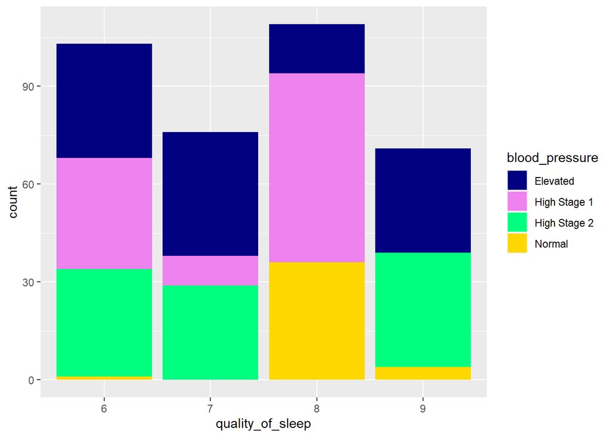

```r
ggplot(sleep, aes(quality_of_sleep)) +
  geom_bar(aes(fill = blood_pressure)) +
  scale_fill_manual(values = c("navy", "violet","springgreen", "gold","indianred", "slategrey"))
```

This result really surprised me as there appears to be no correlation between blood pressure and sleep quality. An individual with a high blood pressure stage 2 has an equal amount of observations in 6,7 and 9 while someone with an elevated blood pressure is also split evenly along 6,7,and 9. There isn’t a clear distinction between one’s blood pressure and their sleep quality.

### Sleep Disorder

Here we want to see how much having a sleep disorder affects sleep quality ratings. In fact it was interesting to see that individuals with sleep apnea still had high sleep quality ratings, those with insomnia did more observations in lower sleep quality ratings which can be expected.

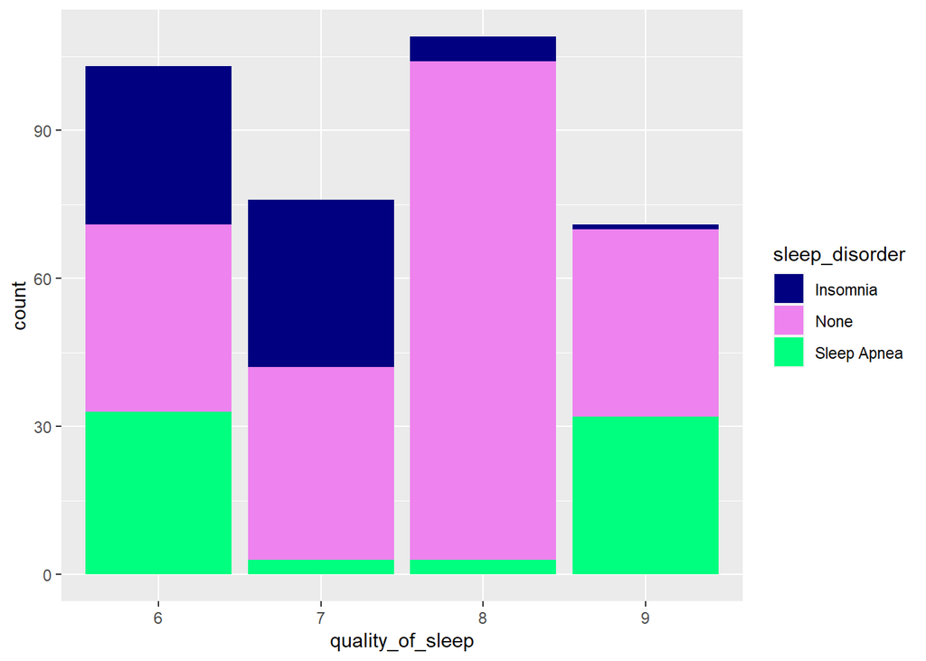

```r
ggplot(sleep, aes(quality_of_sleep)) +
  geom_bar(aes(fill = sleep_disorder)) +
  scale_fill_manual(values = c("navy", "violet","springgreen"))
```

## Setting Up Models

Now we move on to the next part of our prediction models which is to start fitting and setting up our models. At this point we have an idea of how our variables interact and their relationships so we can start with splitting the data into training and testing data, create the recipe, and create the folds for cross validation.

### Data Split

As mentioned above we will begin by splitting the data into testing and training sets. The training set trains the models and the testing set evaluates the performance of the models allowing us to see which prediction models performed the best. I will be doing a 70/30 split, 70% for the training set and 30% for the testing set. We want more data for the training set so we have more data to train the model and prevent high bias while still have a good amount for model testing. This also helps prevent over-fitting by which occurs when there is too much data for training so it can’t generalize. We stratify the outcome variable, quality_of_sleep, so both the testing and training data have an equal amount.

```r
set.seed(222) #Create reproducible results
sleep_split <- sleep %>% #Splitting the data
  initial_split(prop = 0.7, strata = "quality_of_sleep")

sleep_train <- training(sleep_split) #Training data split
sleep_test <- testing(sleep_split) #Testing data split

nrow(sleep_train)/nrow(sleep)
```

```
## [1] 0.6963788
```

```r
nrow(sleep_test)/nrow(sleep)
```

```
## [1] 0.3036212
```

We also checked to make sure the split was properly executed 70/30 which was true.

### Recipe Building

We will create one recipe for all our models to use since they will be using the same predictor and outcome variables. However each of the models have their own distinctive actions when applying the recipe.

Our recipe will be using 11 predictors, gender, age, occupation, sleep duration, physical activity level, stress level, bmi category, blood pressure, heart rate, daily steps, and sleep disorder.

We have no missing values so imputing is unnecessary.

Gender, bmi category, sleep disorder, blood pressure, stress level, and occupation will be turned into dummy variables as they are categorical and not continuous.

We normalize the variables with by centering and scaling the numeric data.

```r
sleep_recipe <- recipe(quality_of_sleep ~  gender + age + occupation + sleep_duration + physical_activity_level + stress_level + heart_rate + bmi_category + blood_pressure + daily_steps + sleep_disorder, data = sleep_train) %>%

  step_dummy(all_nominal_predictors()) %>%

  step_normalize(all_predictors())
```

### K-fold Cross Validation

K-fold cross validation is used to evaluate models and help build a more generalized model. In this case we will split our data in 10 folds where the model is trained and evaluated. The k fold is the testing set, validation set, while the k-1 folds are the training sets for that particular testing set. Performance metrics are gathered from each fold and averaged to find performance.

We stratify on the outcome variable, quality_of_sleep.

```r
sleep_folds <- vfold_cv(sleep_train, v = 10, strata = quality_of_sleep)
```

## Model Building

The next step is to finally build our models. For this project we will be using 4 different model types, elastic net, k-nearest neighbors, random forest, and boosted trees. Our metric to measure performance will be ROC AUC which stands for the area under the ROC, receiver operating curve. The ROC is the probability curve and AUC is the measure of separability. It measures how well the model can distinguish positive and negative classes so the higher the score and closer to 1, the better. The models will follow the same series of steps which will be listed below.

### Model Fitting

1st step - Specify the model, tune the parameters, and set the engine and mode for that model.

```r
#K-Nearest Neighbors
sleep_knn_model <- nearest_neighbor(neighbors = tune()) %>%
  set_engine("kknn") %>%
  set_mode("classification")

#Elastic Net
sleep_en_mod <- multinom_reg(mode = "classification", engine = "glmnet",
                             penalty = tune(), mixture = tune())

#Random Forest
sleep_rf_mod <- rand_forest(mtry = tune(),
                            trees = tune(),
                            min_n = tune()) %>%
  set_engine("ranger", importance = "impurity") %>%
  set_mode("classification")

#Boosted Trees
sleep_bt_mod <- boost_tree(mtry = tune(),
                           trees = tune(),
                           learn_rate = tune()) %>%
  set_engine("xgboost") %>%
  set_mode("classification")
```

2nd step - Set up workflows, add the model and recipe to the workflow.

```r
#KNN workflow
knn_wkflow <- workflow() %>%
  add_model(sleep_knn_model) %>%
  add_recipe(sleep_recipe)

#Elastic Net workflow
en_wkflow <- workflow() %>%
  add_model(sleep_en_mod) %>%
  add_recipe(sleep_recipe)

#Random Forest workflow
rf_wkflow <- workflow() %>%
  add_model(sleep_rf_mod) %>%
  add_recipe(sleep_recipe)

#Boosted Tree workflow
bt_wkflow <- workflow() %>%
  add_model(sleep_bt_mod) %>%
  add_recipe(sleep_recipe)
```

3rd step - Create model grids, you can set ranges for your tuned parameters and number of levels.

```r
#K-Nearest Neighbors
knn_grid <- grid_regular(neighbors(range = c(1,10)), levels = 10)


#Elastic Net
en_grid <- grid_regular(penalty(range = c(0,1),
                                trans = identity_trans()),
                        mixture(range = c(0,1)),
                        levels = 10)

#Random Forest
rf_grid <- grid_regular(mtry(range = c(1,8)),
                        trees(range = c(200,600)),
                        min_n(range = c(10,20)),
                        levels = 8)

#Boosted Tree
bt_grid <- grid_regular(mtry(range = c(1, 8)),
                        trees(range = c(200, 600)),
                        learn_rate(range = c(-0.01, 0.1)),
                        levels = 5)
```

4th step - Tune the models, add the workflows, cross validation folds, and the model grids.

```r
#K-Nearest Neighbors
knn_tune <- tune_grid(
  object = knn_wkflow,
  resamples = sleep_folds,
  grid = knn_grid
)

#Elastic Net
en_tune <- tune_grid(
  object = en_wkflow,
  resamples = sleep_folds,
  grid = en_grid
)

#Random Forest
rf_tune <- tune_grid(
  object = rf_wkflow,
  resamples = sleep_folds,
  grid = rf_grid
)

#Boosted Trees
bt_tune <- tune_grid(
  object = bt_wkflow,
  resamples = sleep_folds,
  grid = bt_grid
)
```

5th step - Save results to an RDA file to load back later as running models takes an long period of time and we want to rerun the models as few times as possible.

```r
saveRDS(knn_tune, file = "knn_tune.rda")
saveRDS(en_tune, file = "en_tune.rda")
saveRDS(rf_tune, file = "rf_tune.rda")
saveRDS(bt_tune, file = "bt_tune.rda")
```

```r
readRDS("knn_tune.rda")
readRDS("en_tune.rda")
readRDS("rf_tune.rda")
readRDS("bt_tune.rda")
```

6th step - Look at the accuracy of the models by gathering the metrics and select the tuned models, we are looking at roc_auc or area under the ROC Curve. ROC AUC is measured from 0 to 1, the closer your score to 1, the better the model is at predicting. Then select the most optimal models.

```r
#K-Nearest Neighbors Metrics
knn_metrics <- collect_metrics(knn_tune)
knn_metrics
best_knn <- show_best(knn_tune, metric = "roc_auc", n = 1)

#Elastic Net Metrics
en_metrics <- collect_metrics(en_tune)
en_metrics
best_en <- show_best(en_tune, metric = 'roc_auc', n = 1)

#Random Forest Metrics
rf_metrics <- collect_metrics(rf_tune)
rf_metrics
best_rf <- show_best(rf_tune, metric = 'roc_auc', n = 1)

#Boosted Tree Metrics
bt_metrics <- collect_metrics(bt_tune)
bt_metrics
best_bt <- show_best(bt_tune, metric = 'roc_auc', n = 1)
```

7th step - Fit the models and workflow to training data set.

```r
#K-nearest neighbors fit
final_knn_wkflow <- finalize_workflow(knn_wkflow, best_knn)
knn_fit <- fit(final_knn_wkflow, data = sleep_train)

#Elastic Net fit
final_en_wkflow <- finalize_workflow(en_wkflow, best_en)
en_fit <- fit(final_en_wkflow, data = sleep_train)

#Random Forest fit
final_rf_wkflow <- finalize_workflow(rf_wkflow, best_rf)
rf_fit <- fit(final_rf_wkflow, data = sleep_train)

#Boosted Tree fit
final_bt_wkflow <- finalize_workflow(bt_wkflow, best_bt)
bt_fit <- fit(final_bt_wkflow, data = sleep_train)
```

### Model Autoplots

The next step for our models is to create visualizations. The autoplot function in r allows us to see how the tuned parameters impact the performance of the models which we measured with ROC AUC.

#### Elastic Net Autoplot

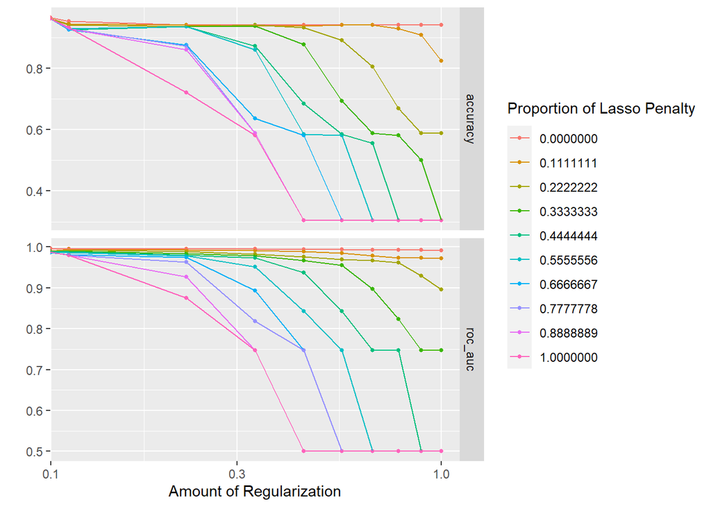

```r
autoplot(en_tune)
```

#### K-Nearest Neighbor Autoplot

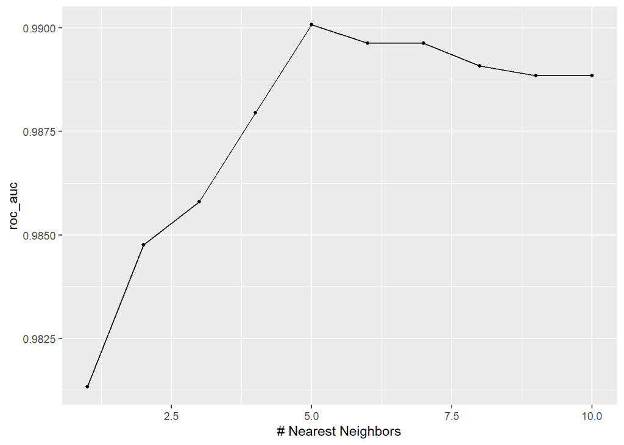

```r
autoplot(knn_tune, metric = 'roc_auc')
```

#### Random Forest Autoplot

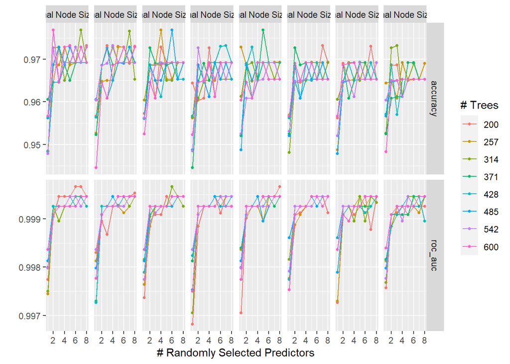

```r
autoplot(rf_tune)
```

For our random forest plot the range of mtry was from 1 to 8, trees from 200 to 600, and min_n 10 to 20. It seems that as mtry, randomly selected predictors, increases up to around 2, performance improves as the ROC AUC increases and beyond that it remains in the 0.999 range which is outstanding. The number of trees does not make much of a difference as all the lines are near one another. Minimal node size also does not make much of an effect but a few different number of trees performed slightly better with a smaller minimal node size.

#### Boosted Tree Autoplot

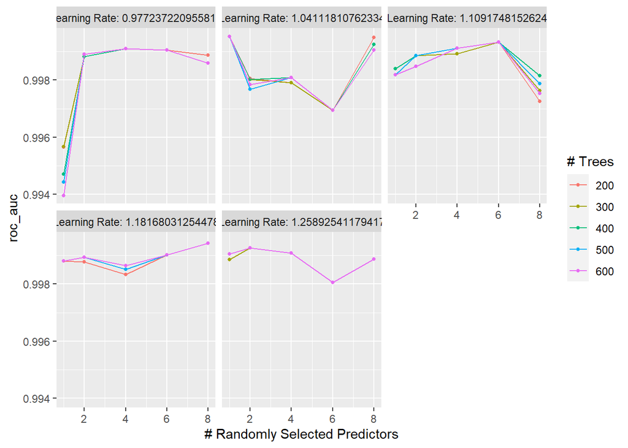

```r
autoplot(bt_tune, metric = 'roc_auc')
```

### Model Results

With our models completed, we can finally compare their metrics to find the best performing one.

```r
sleep_knn_auc <- augment(knn_fit, new_data = sleep_train) %>%
  select(quality_of_sleep, starts_with(".pred")) %>%
  roc_auc(quality_of_sleep, .pred_6:.pred_9) %>%
  select(.estimate)
sleep_knn_auc


sleep_en_auc <- augment(en_fit, new_data = sleep_train) %>%
  select(quality_of_sleep, starts_with(".pred")) %>%
  roc_auc(quality_of_sleep, .pred_6:.pred_9) %>%
  select(.estimate)
sleep_en_auc

sleep_rf_auc <- augment(rf_fit, new_data = sleep_train) %>%
  select(quality_of_sleep, starts_with(".pred")) %>%
  roc_auc(quality_of_sleep, .pred_6:.pred_9) %>%
  select(.estimate)
sleep_rf_auc

sleep_bt_auc <- augment(bt_fit, new_data = sleep_train) %>%
  select(quality_of_sleep, starts_with(".pred")) %>%
  roc_auc(quality_of_sleep, .pred_6:.pred_9) %>%
  select(.estimate)
sleep_bt_auc
```

```r
# We will be creating a tibble that displays the models and their ROC AUC score
Model_compare <- tibble(Model = c("K Nearest Neighbors", "Elastic Net", "Random Forest", "Boosted Trees"), roc_auc = c(sleep_knn_auc$.estimate, sleep_en_auc$.estimate, sleep_rf_auc$.estimate , sleep_bt_auc$.estimate))

#Descending order
Model_compare <- Model_compare %>%
  arrange(desc(roc_auc))

Model_compare
```

```
## # A tibble: 4 × 2
##   Model                 roc_auc
##   <chr>                   <dbl>
## 1 K Nearest Neighbors 1
## 2 Random Forest       1
## 3 Boosted Trees       1
## 4 Elastic Net         0.9996694
```

WOW this means that the K-nearest neighbors, random forest, and boosted trees all had perfect predictions. This however can be explained by the small number of observations in the data set, some of the variables had did not have all of their possible values in the data set while others had too few observations for unique values. Therefore the models had to be condensed down onto a select few values for some variables, the model would be unable to predict some values or use other values as predictors in this case and thus making it easier to predict. To find the best model, we will be getting the optimal value of each model to compare.

```r
# We will be creating a tibble that displays the models and their ROC AUC score
Model_compare <- tibble(Model = c("K Nearest Neighbors", "Elastic Net", "Random Forest", "Boosted Trees"), roc_auc = c(best_knn$mean, best_en$mean, best_rf$mean, best_bt$mean))

#Descending order
Model_compare <- Model_compare %>%
  arrange(desc(roc_auc))

Model_compare
```

```
## # A tibble: 4 × 2
##   Model                 roc_auc
##   <chr>                   <dbl>
## 1 Random Forest       0.9996615
## 2 Boosted Trees       0.9995312
## 3 Elastic Net         0.9963904
## 4 K Nearest Neighbors 0.9900800
```

Based on the model comparisons, the random forest model had the best performance with a roc_auc score of 0.9996 which is really outstanding. In second was the boosted trees model which was really close behind with a ROC AUC score of 0.9995. Now that we found our best model we have to now evaluate its performance on the testing set.

### Best Model Results

With our best model now being the random forest model, we can now examine its results. We will be evaluating its performance on the testing set, new data.

#### Random Forest Model

```r
rf_tune %>%
  collect_metrics() %>%
  arrange(desc(mean)) %>%
  slice(1)
```

```
## # A tibble: 1 × 9
##    mtry trees min_n .metric .estimator      mean     n      std_err .config
##   <int> <int> <int> <chr>   <chr>          <dbl> <int>        <dbl> <chr>
## 1     6   200    10 roc_auc hand_till  0.9996615    10 0.0002330854 Preprocesso…
```

Random Forest #6 had the best performance with a ROC AUC score of 0.9996 as seen above. In terms of its parameters it had a mtry of 6, 200 trees, and minimal node size of 10. Let’s now assess it with the testing set.

```r
options(digits = 7)
augment(rf_fit, new_data = sleep_test) %>%
  select(quality_of_sleep, starts_with(".pred")) %>%
  roc_auc(quality_of_sleep, .pred_6:.pred_9) %>%
  select(.estimate)
```

```
## # A tibble: 1 × 1
##   .estimate
##       <dbl>
## 1 0.9995608
```

It had a slightly lower performance on testing model compared to the average ROC AUC across folds however it still performed really well with a ROC AUC score of 0.9995.

#### Testing the Model

We will now make predictions on the observations in the testing set and see specifically the performance on untrained data.

```r
sleep_predict <- predict(rf_fit, new_data = sleep_test, type = "class")

predict_vs_actual <- sleep_predict %>% bind_cols(sleep_test %>% select(quality_of_sleep))

predict_vs_actual
```

```
## # A tibble: 109 × 2
##    .pred_class quality_of_sleep
##    <fct>       <fct>
##  1 6           6
##  2 6           6
##  3 7           7
##  4 7           7
##  5 7           7
##  6 7           7
##  7 7           7
##  8 7           7
##  9 7           7
## 10 7           7
## # ℹ 99 more rows
```

#### Variable Importance Plot

Let’s take a look at which predictor variables were most useful in the random forest model. We will use training data as the random forest model was fitted to it.

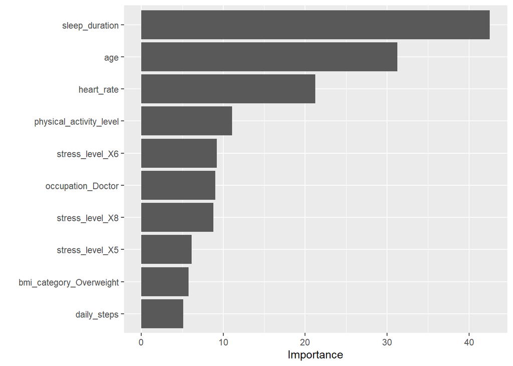

#### ROC Curve

Let’s plot a ROC Curve to visualize the ROC AUC scores. The closer the curve is to the Greek letter Γ, the better. As we can see most of our plots are like that but the model did have trouble predicting ratings of 7.

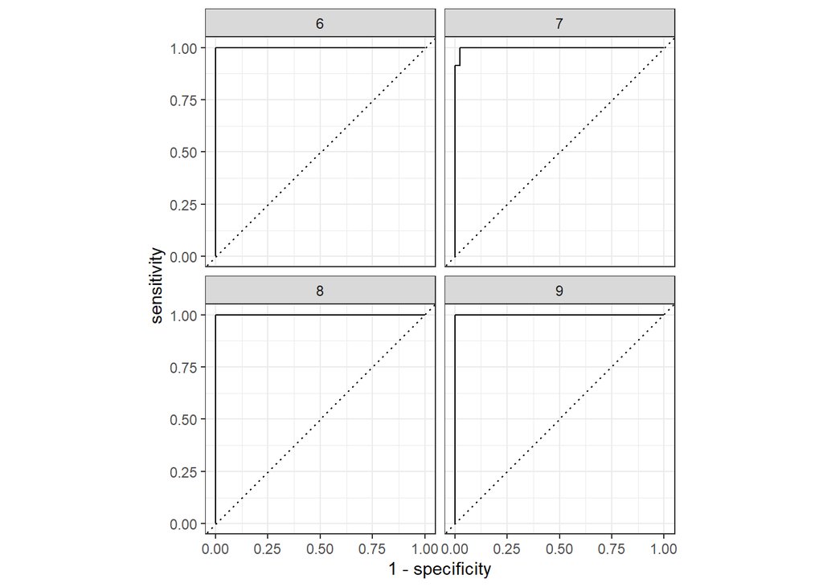

```r
sleep_roc_curve <- augment(rf_fit, new_data = sleep_test) %>%
  select(quality_of_sleep, starts_with(".pred")) %>%
  roc_curve(quality_of_sleep, .pred_6:.pred_9)

autoplot(sleep_roc_curve)
```

### Conclusion

[figure not shown]

All in all after analyzing and fitting our models, the random forest model proved to be the best while K-nearest neighbors performed the worst. This was expected as the random forest model is really flexible and non-sensitive while K-nearest neighbors is highly sensitive. However all the models had incredible ROC AUC scores so they weren’t too far behind, meaning they all could predict with near perfection.

There are a few flaws with this data set however, there were too few observations and variables had potential values which were not represented by individuals or had values that had too few individuals so we could not use them for our predictions since they would not be enough to develop a correlation. In the future a bigger data set that encompasses more diverse individuals and more observations would improve this model.

To conclude, building these models to attempt to predict sleep quality was a great way for me to learn more about machine learning and get my hands wet. It was really fun to see how all the parts fit together and getting the results from the models to compare them was really exciting. In the future I could try to implement more, different models and really explore machine learning.

### Sources

Data is from the Kaggle data set, [Sleep and Lifestyle Dataset](https://www.kaggle.com/datasets/uom190346a/sleep-health-and-lifestyle-dataset/data), observations gathered by user Lakiska Tharmalingam.

Information about sleep was gathered from [SleepHealth.org](https://www.sleephealth.org/sleep-health/the-state-of-sleephealth-in-america/), American Psychological Association, and Centers for Disease Control and Prevention.